# PCA: extracting socio-economic information in the world

Advanced Modelling, Master in Computational Social Science

UC3M, 2026

# 1 Introduction

## 1.1 Motivation

Can we organize the world’s countries by variables we are interested in?

For instance, the World Bank organizes countries in 4 income groups using only the Gross National Income (GNI) per capita. However, development can be measured using more dimensions—health, education, Internet access, among others.

A classic example is the Human Development Index (HDI) used by the United Nations, which aggregates three main variables: life expectancy, education, and income. It is quite interpretable, but obviously does not incorporate every possible dimension.

Principal Component Analysis (PCA) offers a data-driven way to collapse many correlated variables into fewer components, potentially revealing an overall, multi-dimensional measure of development. In other words:

- How can we define a Development Index that includes more information, such as infant mortality, hospital beds, Internet usage, etc.?
- How does this PCA-based index compare to simpler indices (e.g., HDI-like) that only use a few indicators?

In this case study, we will explore countries’ socio-economic and health indicators from the World Health Organization (WHO) data, create a PCA-based development index, and compare it with simpler approaches.

## 1.2 Setup

```r
library(tidyverse)
library(GGally) # ggplot2-based visualization of correlations
library(factoextra) # ggplot2-based visualization of pca
library(countrycode)
library(rworldmap)
library(mice) # Use for data imputation
library(plotly)
```

# 2 Data Exploration

## 2.1 The Dataset

The dataset is obtained through the notebook “2.0-socioeconomic-WHO-preprocessing.Rmd”, which creates a file named “WorldData2025.txt”. There you can find explanation for the following World Health Organization (WHO) variables:

- Life expectancy at birth (years)
- Infant mortality rate (probability of dying between birth and age 1 per 1000 live births)
- Population (in thousands) total
- Ambient air pollution (Annual PM2.5 [ug/m3])
- Estimates of rates of homicides per 100 000 population
- Health expenditure as percentage of GDP (%)
- Medical doctors (per 10 000 population)
- Hospital beds (per 10 000 population)
- Percentage of individuals using the Internet
- Literacy rate (% of people ages 15 and above)
- Expected Years Of School
- Unemployment, total (% of total labor force)
- GDP per capita (constant 2017 US$)

```r
WHO = read.table("WorldData2025.txt", sep=",")
```

## 2.2 Descriptive Analysis

Some preliminary analysis:

```r
# Explore data dimensions and structure
dim(WHO)
```

```
## [1] 226  18
```

```r
str(WHO)
```

```
## 'data.frame':    226 obs. of  18 variables:
##  $ Country       : chr  "Aruba" "Afghanistan" "Angola" "Anguilla" ...
##  $ COUNTRY       : chr  "ABW" "AFG" "AGO" "AIA" ...
##  $ Continent     : chr  "Americas" "Asia" "Africa" "Americas" ...
##  $ Region        : chr  "Latin America & Caribbean" "South Asia" "Sub-Saharan Africa" "Latin America & Caribbean" ...
##  $ LifeExpectancy: num  NA 61.2 62 NA 77.9 ...
##  $ IMR           : num  NA 110.08 53.63 13.61 8.31 ...
##  $ Population    : num  108 42647 37886 NA 2377 ...
##  $ AirPollution  : num  NA 70.3 25.9 NA 18.1 ...
##  $ HomicidesRate : num  NA 8.33 9.22 NA 3.73 ...
##  $ HealthExp     : num  NA 14.99 2.6 NA 7.36 ...
##  $ MedicalDoctors: num  NA 2.45 2.44 NA 16.45 ...
##  $ HospitalBeds  : num  NA 3.53 NA NA 28.37 ...
##  $ Internet      : num  NA 5.45 16.94 NA 54.66 ...
##  $ Literacy      : num  96.8 37.3 66.2 NA 97.7 ...
##  $ capital       : chr  "Oranjestad" "Kabul" "Luanda" NA ...
##  $ SchoolYears   : num  NA 8.9 8.12 NA 12.89 ...
##  $ Unemployment  : num  NA 13.7 14 NA 10.7 ...
##  $ GDP           : num  44559 1984 8902 NA 20591 ...
```

```r
head(WHO)
```

```
##       Country COUNTRY Continent                    Region LifeExpectancy
## 1       Aruba     ABW  Americas Latin America & Caribbean             NA
## 2 Afghanistan     AFG      Asia                South Asia       61.22381
## 3      Angola     AGO    Africa        Sub-Saharan Africa       62.03683
## 4    Anguilla     AIA  Americas Latin America & Caribbean             NA
## 5     Albania     ALB    Europe     Europe & Central Asia       77.93852
## 6     Andorra     AND    Europe     Europe & Central Asia             NA
##          IMR Population AirPollution HomicidesRate HealthExp MedicalDoctors
## 1         NA    107.995           NA            NA        NA             NA
## 2 110.075927  42647.492     70.25405      8.325070 14.985763           2.45
## 3  53.625590  37885.849     25.85236      9.222727  2.600410           2.44
## 4  13.608006         NA           NA            NA        NA             NA
## 5   8.314521   2377.128     18.14981      3.733701  7.357504          16.45
## 6   2.651405     81.938      9.94171            NA  6.719663          45.35
##   HospitalBeds Internet Literacy    capital SchoolYears Unemployment       GDP
## 1           NA       NA    96.82 Oranjestad          NA           NA 44558.929
## 2      3.52553  5.45455    37.27      Kabul    8.901891       13.687  1983.813
## 3           NA 16.93721    66.24     Luanda    8.120066       14.020  8901.887
## 4           NA       NA       NA       <NA>          NA           NA        NA
## 5     28.37198 54.65596    97.68     Tirane   12.889381       10.689 20591.487
## 6     25.62475 86.43443       NA       <NA>          NA           NA 65928.307
```

```r
summary(WHO)
```

```
##    Country            COUNTRY           Continent            Region
##  Length:226         Length:226         Length:226         Length:226
##  Class :character   Class :character   Class :character   Class :character
##  Mode  :character   Mode  :character   Mode  :character   Mode  :character
##
##
##
##
##  LifeExpectancy       IMR            Population         AirPollution
##  Min.   :51.27   Min.   :  1.414   Min.   :9.650e+00   Min.   : 5.467
##  1st Qu.:66.30   1st Qu.:  7.373   1st Qu.:8.977e+02   1st Qu.:10.762
##  Median :72.90   Median : 16.971   Median :6.916e+03   Median :17.382
##  Mean   :71.79   Mean   : 28.496   Mean   :3.777e+04   Mean   :21.755
##  3rd Qu.:77.26   3rd Qu.: 43.693   3rd Qu.:2.711e+04   3rd Qu.:28.625
##  Max.   :84.46   Max.   :126.941   Max.   :1.451e+06   Max.   :70.254
##  NA's   :40      NA's   :28        NA's   :11          NA's   :30
##  HomicidesRate       HealthExp      MedicalDoctors   HospitalBeds
##  Min.   : 0.1811   Min.   : 1.973   Min.   : 0.39   Min.   :  1.722
##  1st Qu.: 1.8339   1st Qu.: 4.322   1st Qu.: 3.82   1st Qu.: 11.965
##  Median : 4.8175   Median : 6.451   Median :17.10   Median : 25.034
##  Mean   : 8.4857   Mean   : 6.751   Mean   :19.47   Mean   : 31.047
##  3rd Qu.: 9.0628   3rd Qu.: 8.417   3rd Qu.:31.41   3rd Qu.: 40.532
##  Max.   :90.5472   Max.   :21.288   Max.   :86.09   Max.   :219.887
##  NA's   :42        NA's   :30       NA's   :36      NA's   :54
##     Internet        Literacy        capital           SchoolYears
##  Min.   : 0.80   Min.   : 26.83   Length:226         Min.   : 4.157
##  1st Qu.:12.92   1st Qu.: 76.54   Class :character   1st Qu.: 9.991
##  Median :38.20   Median : 93.91   Mode  :character   Median :12.066
##  Mean   :39.66   Mean   : 85.27                      Mean   :11.298
##  3rd Qu.:63.00   3rd Qu.: 97.96                      3rd Qu.:13.099
##  Max.   :96.00   Max.   :100.00                      Max.   :13.936
##  NA's   :37      NA's   :55                          NA's   :53
##   Unemployment         GDP
##  Min.   : 0.130   Min.   :  1051
##  1st Qu.: 3.278   1st Qu.:  6809
##  Median : 5.199   Median : 18069
##  Mean   : 6.960   Mean   : 27719
##  3rd Qu.: 8.925   3rd Qu.: 41951
##  Max.   :34.643   Max.   :132570
##  NA's   :39       NA's   :27
```

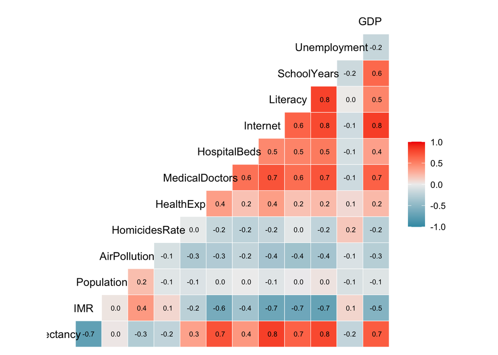

```r
# Visualize the correlation matrix - this motivates PCA
# High correlations between variables suggest redundancy that PCA can exploit
ggcorr(WHO %>% dplyr::select(-Continent,-Region,-Country,-COUNTRY,-capital),
       label = TRUE, label_size = 2.5, hjust = 0.75)
```

We have data for approximately 200 countries with 18 variables of different domains: health (life expectancy, infant mortality), economic (GDP), education (school years, literacy), and infrastructure (internet, hospital beds).

Many variables show high correlations (e.g., GDP with Internet usage, LifeExpectancy with IMR), which suggest that PCA can effectively reduce dimensionality, as it works best when variables are correlated. If all variables were independent, PCA would not compress information effectively.

## 2.3 Pre-Processing

### 2.3.1 Handling Missing Values

```r
#Percentage of Na's?
sapply(WHO, function(x) sum(is.na(x))*100/nrow(WHO))
```

```
##        Country        COUNTRY      Continent         Region LifeExpectancy
##       0.000000       0.000000       0.000000       0.000000      17.699115
##            IMR     Population   AirPollution  HomicidesRate      HealthExp
##      12.389381       4.867257      13.274336      18.584071      13.274336
## MedicalDoctors   HospitalBeds       Internet       Literacy        capital
##      15.929204      23.893805      16.371681      24.336283      25.221239
##    SchoolYears   Unemployment            GDP
##      23.451327      17.256637      11.946903
```

```r
# Remove first countries with no population
WHO = WHO %>% drop_na(Population)
```

Automatic imputation of NAs:

```r
m = 4 # number of multiple imputations
mice_mod <- mice(WHO, m=m, method='rf')
WHO <- complete(mice_mod, action=m)
```

### 2.3.2 Preparing the Data Matrix

```r
X = WHO %>% dplyr::select(-Continent,-Region,-Country, -COUNTRY,-Population,-capital)

# We need to apply the log to the GDP because it is highly asymetric
X$GDP = log(X$GDP)

# We just save the names and continents for the graphs
names=WHO$Country
continent = WHO$Continent
```

The original GDP distribution is highly right-skewed (a few very wealthy countries). Log transformation makes the distribution more symmetric and reduces the influence of outliers.

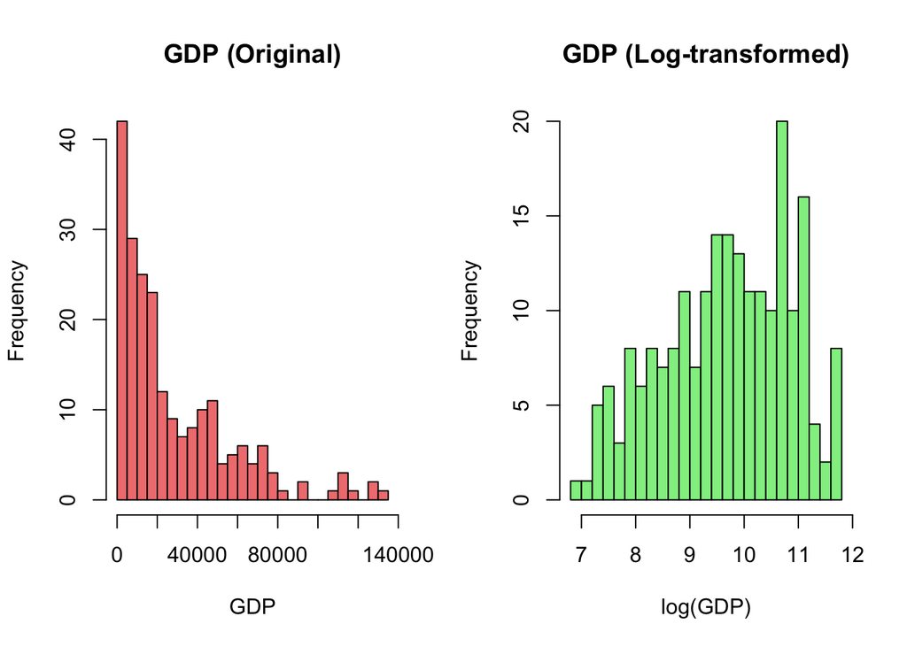

```r
# Compare GDP before and after log transformation
par(mfrow = c(1, 2))
hist(WHO$GDP, breaks = 30, main = "GDP (Original)", col = "lightcoral", xlab = "GDP")
hist(X$GDP, breaks = 30, main = "GDP (Log-transformed)", col = "lightgreen", xlab = "log(GDP)")
```

```r
par(mfrow = c(1, 1))
```

## 2.4 Exploring Variables Before PCA

Before running PCA, let’s understand the variables we’re working with:

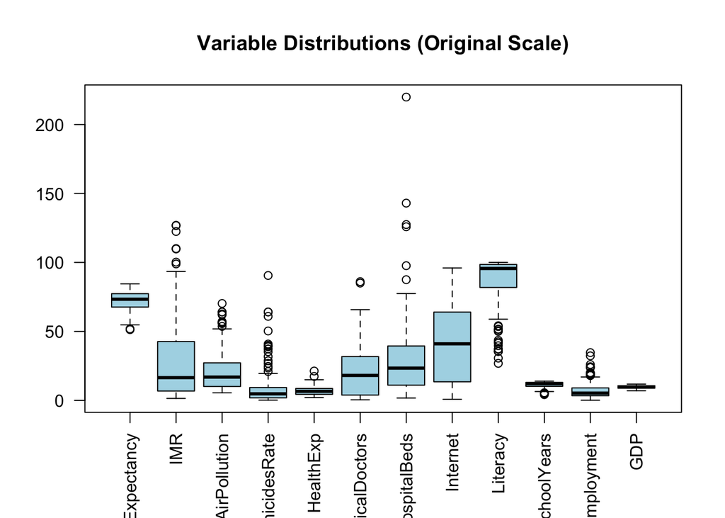

```r
# Distribution of variables before scaling
boxplot(X, las = 2, col = "lightblue", main = "Variable Distributions (Original Scale)")
```

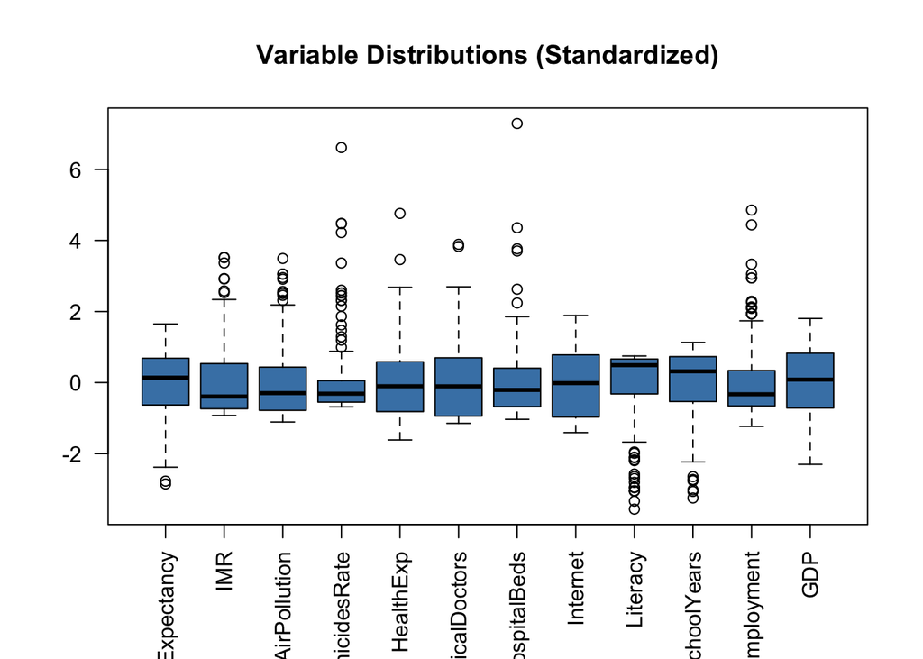

```r
# After scaling - this is what PCA will "see"
boxplot(scale(X), las = 2, col = "steelblue", main = "Variable Distributions (Standardized)")
```

In summary, what we have done to prepare our data is:

1. Log transformation of GDP to make the distribution more symmetric
2. Standardization (`scale. = TRUE` in PCA). This is essential when variables have different units
3. Excluded variables: Population, Country names, Continent, Region. These are identifiers, not development indicators
4. Handle missing data

## 2.5 Basic Data Analysis

```r
# Continent distribution
table(WHO$Continent)
```

```
##
##   Africa Americas     Asia   Europe  Oceania
##       55       45       50       46       19
```

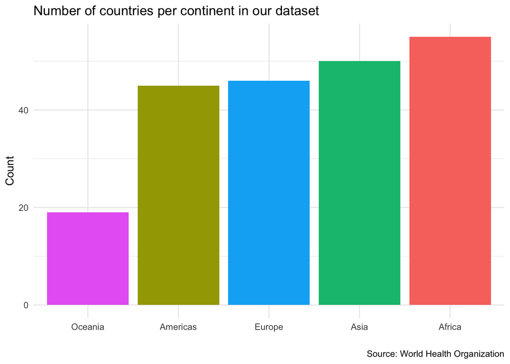

```r
# Better visualization with barplot
WHO %>% ggplot(aes(x=reorder(Continent, Continent, length))) +
  geom_bar(aes(fill=Continent)) +
  labs(title = "Number of countries per continent in our dataset",
       caption = "Source: World Health Organization",
       x = "", y = "Count") +
  theme_minimal() +
  theme(legend.position="none")
```

Which is the country with the highest life expectancy?

```r
# Top 5 countries by life expectancy
WHO %>% arrange(desc(LifeExpectancy)) %>%
  dplyr::select(Country, LifeExpectancy, GDP, IMR) %>% head(5)
```

```
##                 Country LifeExpectancy       GDP      IMR
## 104               Japan       84.46067  46106.92 2.330376
## 179           Singapore       83.99654 132569.53 7.302679
## 88  Hong Kong SAR China       83.09218  66153.97 2.040626
## 111         South Korea       83.09218  55070.94 2.929430
## 126              Monaco       83.09218  91105.25 4.071385
```

And the country with the highest GDP? Are they the same?

```r
# Top 5 countries by GDP
WHO %>% arrange(desc(GDP)) %>%
  dplyr::select(Country, GDP, LifeExpectancy) %>% head(5)
```

```
##        Country      GDP LifeExpectancy
## 179  Singapore 132569.5       83.99654
## 75   Gibraltar 128475.3       82.82955
## 122 Luxembourg 128475.3       82.82955
## 96     Ireland 119037.7       79.58287
## 48        Cuba 111693.5       78.14354
```

```r
# Map of Life Expectancy by country
map_le = WHO %>% dplyr::select(Country, LifeExpectancy)
map_le$country = countrycode(map_le$Country, 'country.name', 'iso3c')
matched_le <- joinCountryData2Map(map_le, joinCode = "ISO3", nameJoinColumn = "country")
```

```
## 214 codes from your data successfully matched countries in the map
## 1 codes from your data failed to match with a country code in the map
## 30 codes from the map weren't represented in your data
```

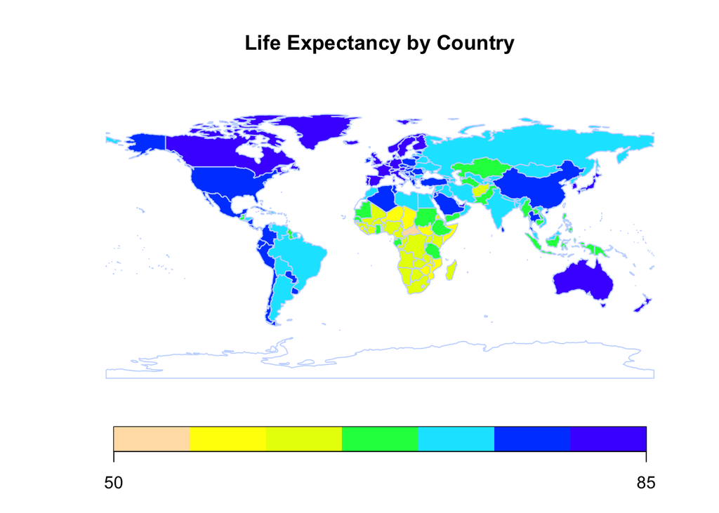

```r
mapCountryData(matched_le, nameColumnToPlot="LifeExpectancy", missingCountryCol = "white",
               borderCol = "#C7D9FF", catMethod = "pretty", colourPalette = "topo",
               mapTitle = c("Life Expectancy by Country"), lwd=1)
```

## 2.6 Multivariate Visualizations

One of the main goals of PCA is to reduce dimensionality so we can visualize our observations in a lower dimensional space such as 2D.

With our original data, before PCA, we can plot several dimensions using 2D plots, groups, colors and size, but this cannot scale much more and real data can have in many cases tens or hundreds of variables.

For instance, this is plot covers 5 dimensions using a scatterplot (2D) of Life Expectancy vs Medical Doctors, grouping by continent, coloring by GDP and changing the size by population:

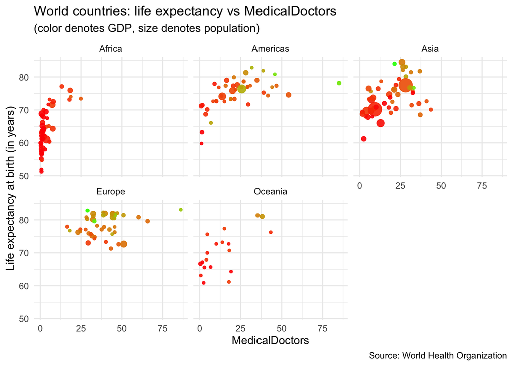

```r
ggplot(WHO, aes(x=MedicalDoctors, y=LifeExpectancy, group=Continent, size=Population, color=GDP)) + geom_point(alpha=0.9) +
  facet_wrap(~ Continent) +
  scale_color_gradient(low="red", high="green") +
  theme_minimal()+ theme(legend.position="none") +
  labs(title = "World countries: life expectancy vs MedicalDoctors", subtitle="(color denotes GDP, size denotes population)",caption="Source: World Health Organization",
       x = "MedicalDoctors", y = "Life expectancy at birth (in years)")
```

# 3 Principal Component Analysis

A single variable ranking (like GDP alone) does not capture the whole complexity of this data. Therefore, lets try to get a unified index of development that uses all variables simultaneously, with the help of PCA.

## 3.1 Computing PCA

When variables have different units (as in our case: years, percentages, dollars…), we should use the correlation matrix instead of the covariance matrix. This is equivalent to standardizing the data first as seen in the slides. With `prcomp()` this is done by setting the parameter `scale.=TRUE`.

```r
# Compute PCA using the correlation matrix (scale. = TRUE)
pca = prcomp(X, scale. = TRUE)

# View the summary - shows variance explained by each component
summary(pca)
```

```
## Importance of components:
##                           PC1    PC2     PC3     PC4    PC5    PC6     PC7
## Standard deviation     2.4522 1.1872 0.95773 0.91077 0.8457 0.8064 0.63841
## Proportion of Variance 0.5011 0.1174 0.07644 0.06912 0.0596 0.0542 0.03396
## Cumulative Proportion  0.5011 0.6186 0.69501 0.76414 0.8237 0.8779 0.91190
##                            PC8     PC9    PC10    PC11    PC12
## Standard deviation     0.58293 0.50007 0.42657 0.38754 0.36767
## Proportion of Variance 0.02832 0.02084 0.01516 0.01252 0.01127
## Cumulative Proportion  0.94022 0.96106 0.97622 0.98873 1.00000
```

```r
# Show structure of PCA results
names(pca)
```

```
## [1] "sdev"     "rotation" "center"   "scale"    "x"
```

The `prcomp()` output contains several elements

- `pca$rotation`: the **loadings** (eigenvectors), which shows how each variable contributes to each PC
- `pca$x`: the **scores**, which is the transformed data (countries in PC space)
- `pca$sdev`: standard deviations of each PC (square root of eigenvalues)

## 3.2 Choosing the Number of Components

How many principal components should we retain? There are several approaches:

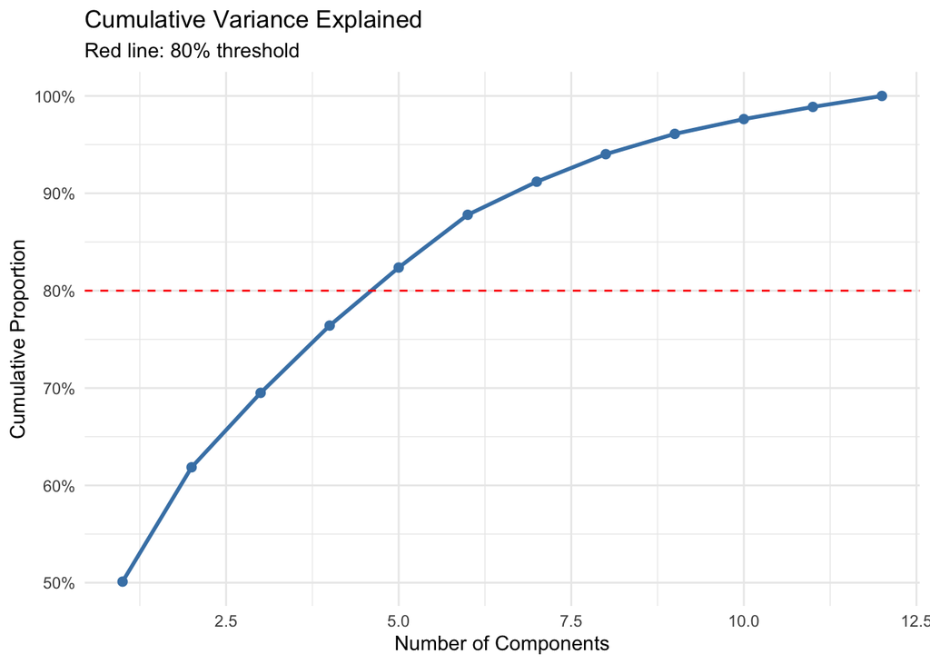

```r
# Method 1: Cumulative variance plot
var_explained <- cumsum(pca$sdev^2 / sum(pca$sdev^2))

data.frame(PC = 1:length(var_explained),
           CumulativeVar = var_explained) %>%
  ggplot(aes(x = PC, y = CumulativeVar)) +
  geom_line(color = "steelblue", linewidth = 1) +
  geom_point(color = "steelblue", size = 2) +
  geom_hline(yintercept = 0.8, linetype = "dashed", color = "red") +
  labs(title = "Cumulative Variance Explained",
       subtitle = "Red line: 80% threshold",
       x = "Number of Components", y = "Cumulative Proportion") +
  scale_y_continuous(labels = scales::percent) +
  theme_minimal()
```

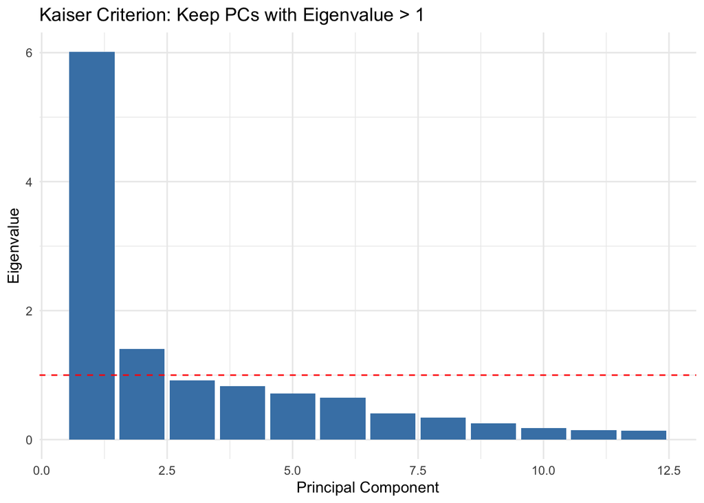

```r
# Method 2: Kaiser criterion (eigenvalues > 1 for correlation-based PCA)
eigenvalues <- pca$sdev^2

data.frame(PC = 1:length(eigenvalues), Eigenvalue = eigenvalues) %>%
  ggplot(aes(x = PC, y = Eigenvalue)) +
  geom_bar(stat = "identity", fill = "steelblue") +
  geom_hline(yintercept = 1, linetype = "dashed", color = "red") +
  labs(title = "Kaiser Criterion: Keep PCs with Eigenvalue > 1",
       x = "Principal Component", y = "Eigenvalue") +
  theme_minimal()
```

```r
cat("Number of components with eigenvalue > 1:", sum(eigenvalues > 1))
```

```
## Number of components with eigenvalue > 1: 2
```

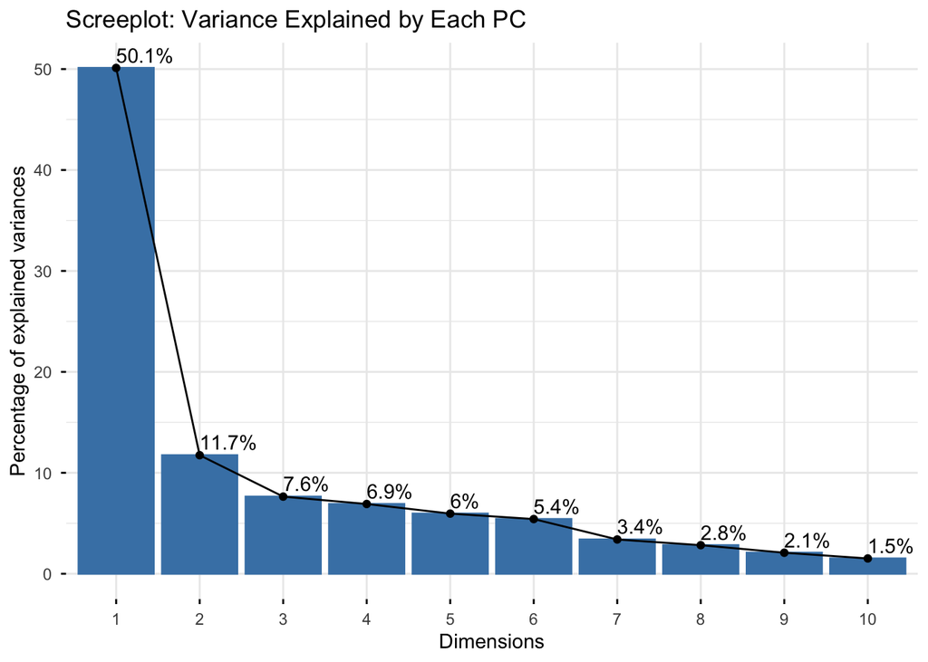

```r
# Method 3: Scree plot (Search for the "elbow" shape, where there is a drastic change in the variance explained gains)
fviz_screeplot(pca, addlabels = TRUE, title = "Screeplot: Variance Explained by Each PC")
```

## 3.3 First Component: A Development Index?

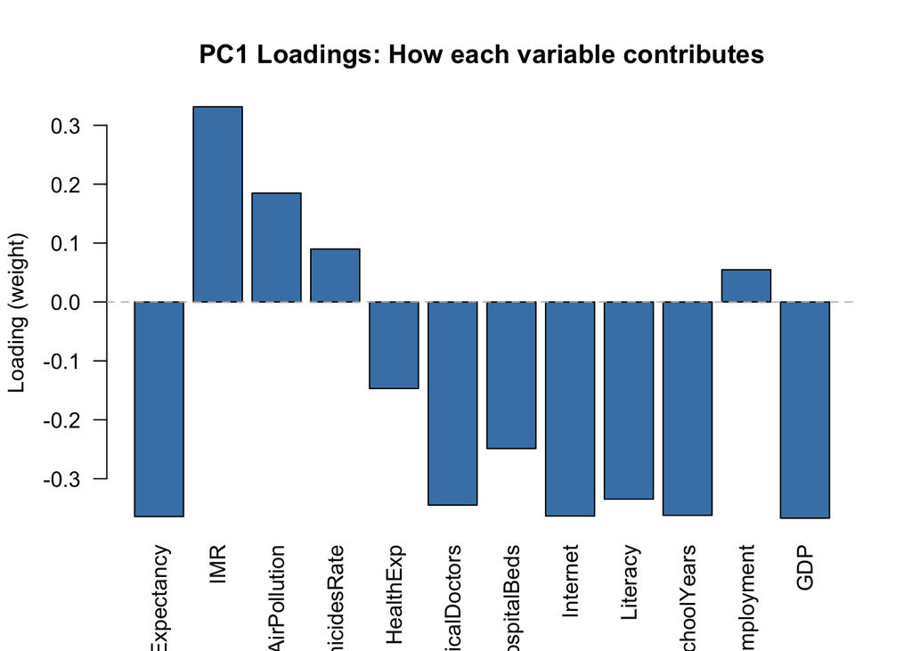

```r
# Visualize PC1 loadings
barplot(pca$rotation[,1], las=2, col="steelblue",
        main="PC1 Loadings: How each variable contributes",
        ylab="Loading (weight)")
abline(h=0, col="gray", lty=2)
```

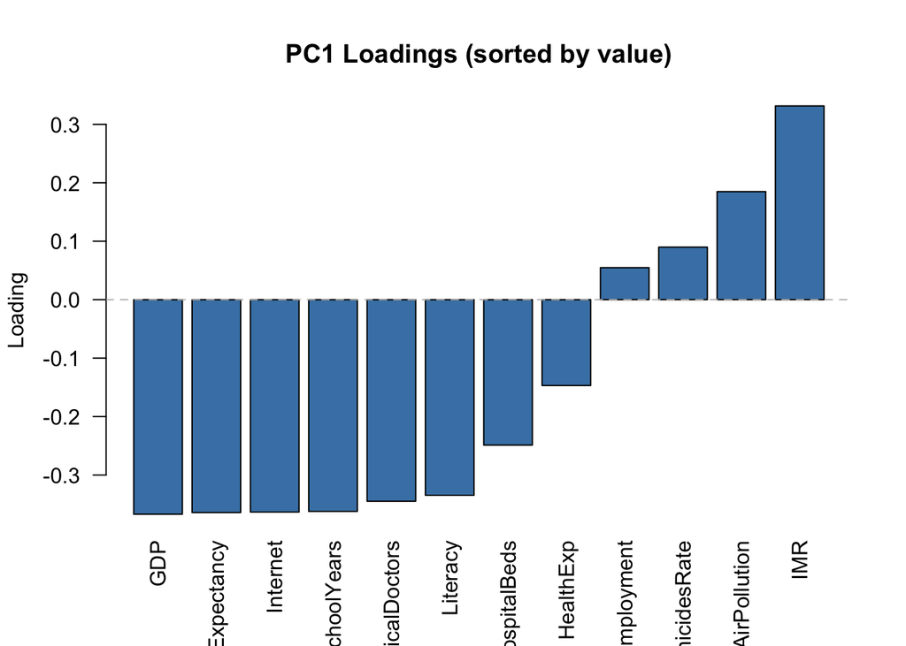

```r
# Sorted by magnitude for clearer interpretation
loadings_pc1 <- pca$rotation[,1]
barplot(sort(loadings_pc1), las=2, col="steelblue",
        main="PC1 Loadings (sorted by value)",
        ylab="Loading")
abline(h=0, col="gray", lty=2)
```

```r
# Numeric view of loadings
round(pca$rotation[,1], 3)
```

```
## LifeExpectancy            IMR   AirPollution  HomicidesRate      HealthExp
##         -0.364          0.331          0.185          0.090         -0.147
## MedicalDoctors   HospitalBeds       Internet       Literacy    SchoolYears
##         -0.345         -0.249         -0.363         -0.335         -0.362
##   Unemployment            GDP
##          0.055         -0.367
```

**The “sign flip” issue:** PCA components are unique only up to sign. If your PC1 shows opposite signs, the interpretation is the same (just flip the ranking direction). The relative signs between variables is what matters.

We can also plot squared loadings instead: they are like percentages (numbers between 0 and 1), but we lose the sign. They can be seen as the contribution of variables to components in absolute magnitude:

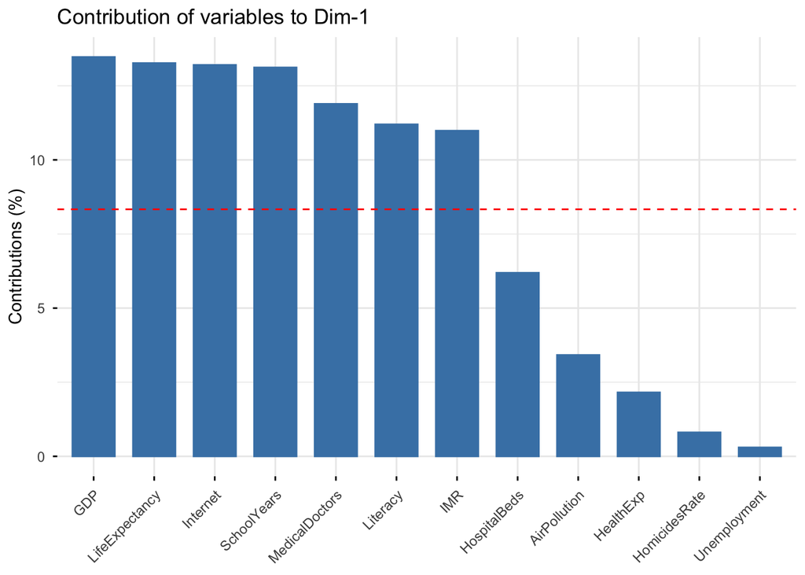

```r
fviz_contrib(pca, choice = "var", axes = 1)
```

The red dashed line on the graph above indicates the expected average contribution. If the contribution of the variables were uniform, the expected value would be 1/length(variables) = 1/12 = 8%.

We can also see what are the countries with higher or lower scores in this PC1.

```r
cat("Countries with LOWEST PC1 (most developed):\n")
```

```
## Countries with LOWEST PC1 (most developed):
```

```r
names[order(pca$x[,1])][1:10]
```

```
##  [1] "Monaco"      "Japan"       "Austria"     "Germany"     "South Korea"
##  [6] "Switzerland" "Norway"      "Sweden"      "Bermuda"     "Netherlands"
```

```r
cat("\nCountries with HIGHEST PC1 (least developed):\n")
```

```
##
## Countries with HIGHEST PC1 (least developed):
```

```r
names[order(pca$x[,1], decreasing=T)][1:10]
```

```
##  [1] "Central African Republic" "Chad"
##  [3] "Niger"                    "Guinea"
##  [5] "South Sudan"              "Somalia"
##  [7] "Mali"                     "Afghanistan"
##  [9] "Liberia"                  "Senegal"
```

## 3.4 Second Component: What Else Does It Capture?

While PC1 captured overall development, what does PC2 represent?

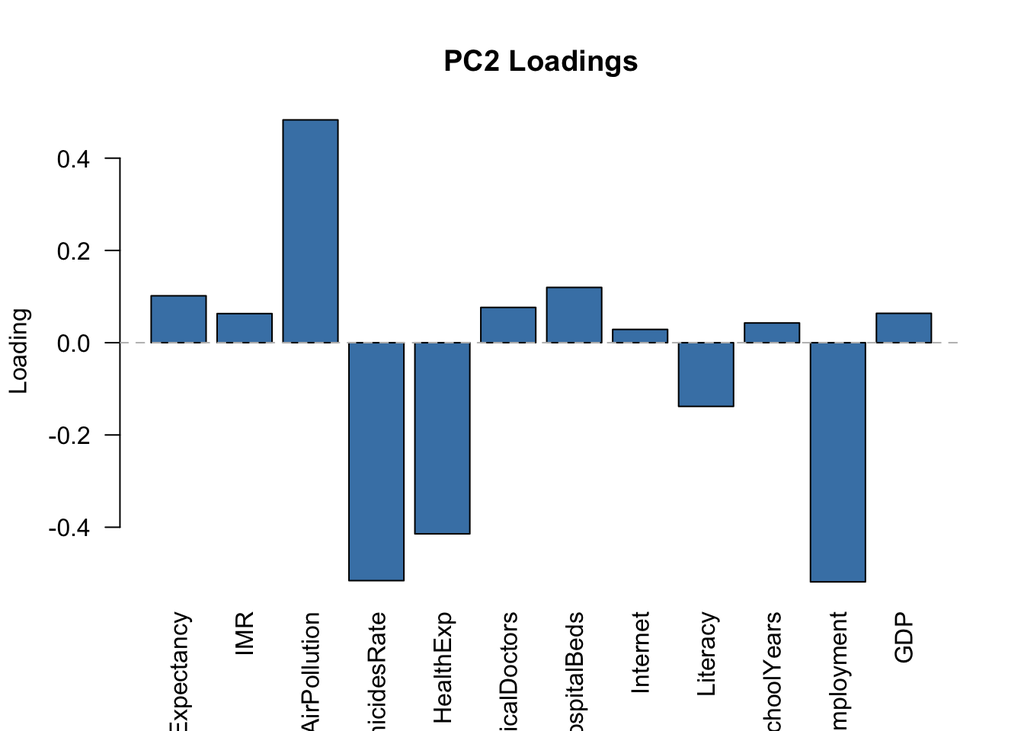

```r
barplot(pca$rotation[,2], las=2, col="steelblue",
        main = "PC2 Loadings",
        ylab = "Loading")
abline(h=0, col="gray", lty=2)
```

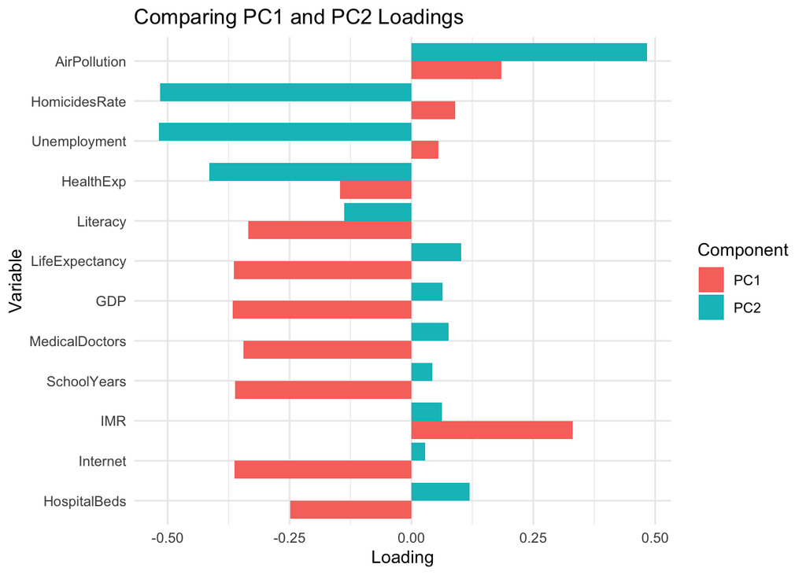

```r
# Compare PC1 and PC2 loadings side by side
loadings_df <- data.frame(
  Variable = rownames(pca$rotation),
  PC1 = pca$rotation[,1],
  PC2 = pca$rotation[,2]
)

loadings_df %>%
  pivot_longer(cols = c("PC1", "PC2"), names_to = "Component", values_to = "Loading") %>%
  ggplot(aes(x = reorder(Variable, abs(Loading)), y = Loading, fill = Component)) +
  geom_bar(stat = "identity", position = "dodge") +
  coord_flip() +
  labs(title = "Comparing PC1 and PC2 Loadings",
       x = "Variable", y = "Loading") +
  theme_minimal()
```

Maybe we can get more insights by ranking the countries using this component:

```r
cat("Countries with LOWEST PC2 scores:\n")
```

```
## Countries with LOWEST PC2 scores:
```

```r
names[order(pca$x[,2])][1:5]
```

```
## [1] "Tuvalu"           "South Africa"     "Marshall Islands" "Eswatini"
## [5] "El Salvador"
```

```r
cat("\nCountries with HIGHEST PC2 scores:\n")
```

```
##
## Countries with HIGHEST PC2 scores:
```

```r
names[order(pca$x[,2], decreasing=T)][1:5]
```

```
## [1] "Qatar"        "Kuwait"       "Bahrain"      "Monaco"       "Saudi Arabia"
```

Contribution of variables to second component:

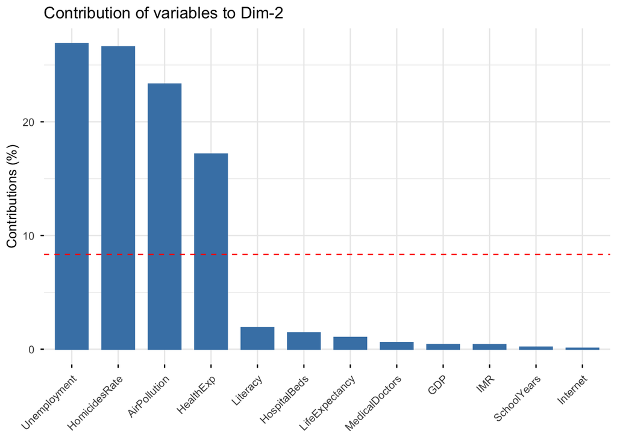

```r
fviz_contrib(pca, choice = "var", axes = 2)
```

Unlike PC1, the second component seems harder to interpret. Any ideas?

By construction, PC2 is **uncorrelated** with PC1. Knowing a country’s development level (PC1) tells you nothing about its PC2 score.

# 4 PCA Visualizations

The `factoextra` package provides elegant visualizations that combine multiple aspects of PCA results.

## 4.1 Biplot: Variables and Countries Together

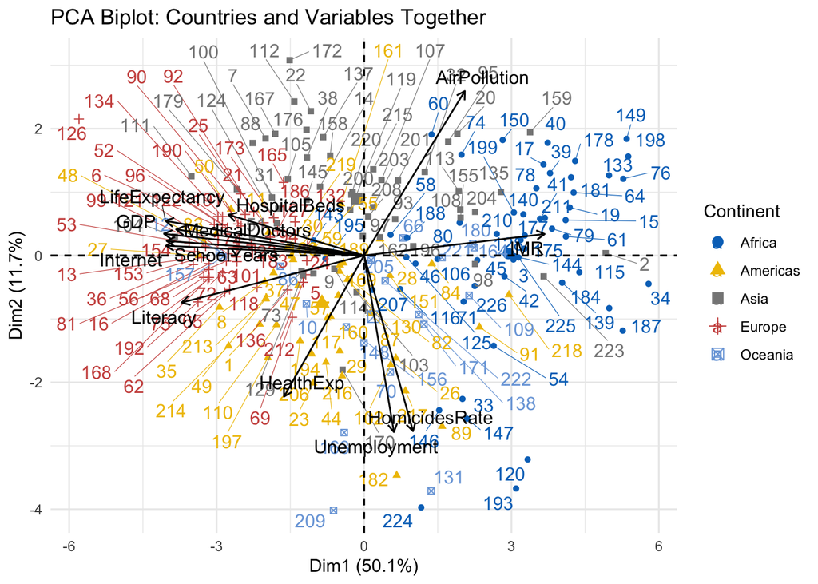

```r
# Biplot shows both variables (arrows) and individuals (points)
# Note: We use habillage for grouping individuals by continent
fviz_pca_biplot(pca,
                repel = TRUE,
                col.var = "black",
                habillage = continent,
                palette = "jco",
                legend.title = "Continent") +
  labs(title = "PCA Biplot: Countries and Variables Together") +
  theme_minimal()
```

**Reading the Biplot:**

- **Arrows (variables)**: Direction shows correlation with PCs; length indicates contribution
- **Points (countries)**: Position shows their PC scores
- **Proximity**: Variables pointing in similar directions are positively correlated

## 4.2 Variable Correlation Circle

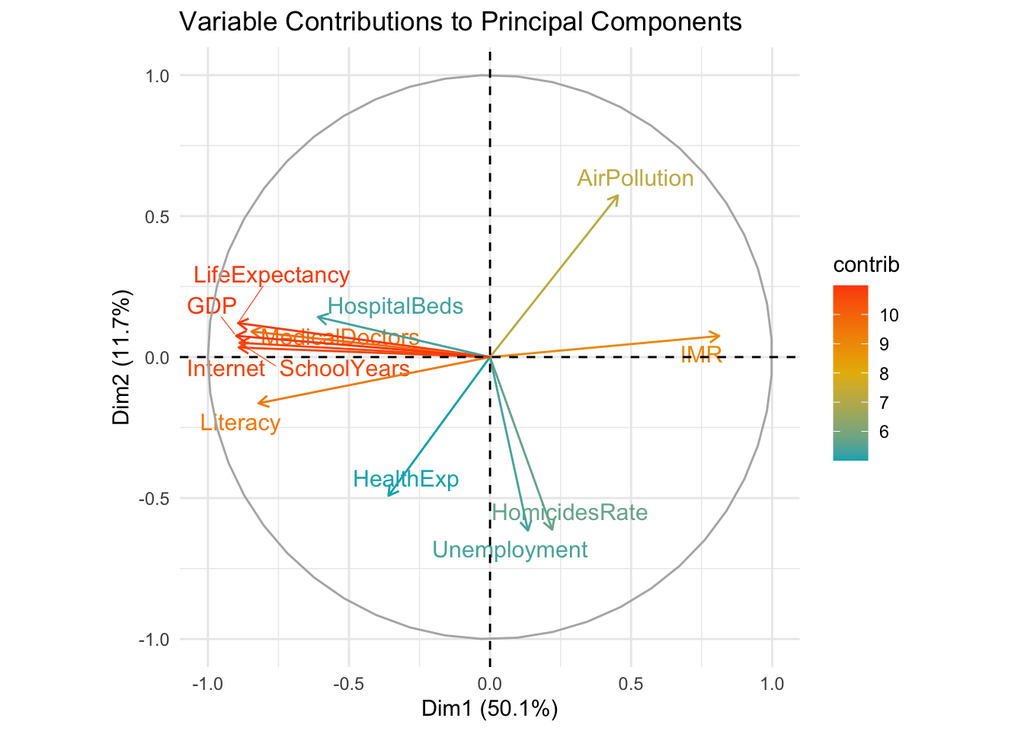

```r
fviz_pca_var(pca,
             col.var = "contrib",
             gradient.cols = c("#00AFBB", "#E7B800", "#FC4E07"),
             repel = TRUE) +
  labs(title = "Variable Contributions to Principal Components") +
  theme_minimal()
```

**The Correlation Circle:**

- Variables close together are positively correlated
- Variables at 180 degrees are negatively correlated
- Variables at 90 degrees are uncorrelated
- The closer to the circle edge, the better represented by PC1+PC2

## 4.3 Scores Plot with Labels

The scores plot shows each country positioned in the 2D space defined by PC1 and PC2:

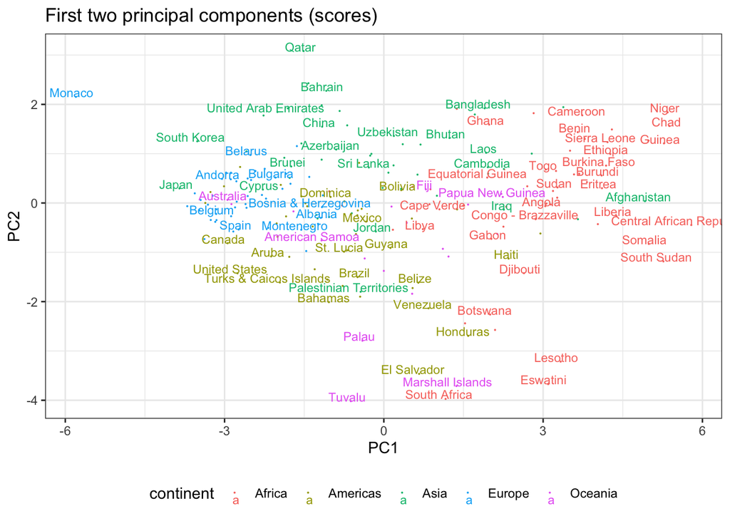

```r
data.frame(z1=pca$x[,1],z2=pca$x[,2]) %>%
  ggplot(aes(z1,z2,label=names,color=continent)) + geom_point(size=0) +
  labs(title="First two principal components (scores)", x="PC1", y="PC2") +
  theme_bw() +theme(legend.position="bottom") + geom_text(size=3, hjust=0.6, vjust=0, check_overlap = TRUE)
```

# 5 Regions and comparison with HDI

## 5.1 Regional Development Rankings

Which regions (using the `Region` variable in our data) have the most developed countries on average?

```r
data.frame(z1=pca$x[,1],Region=WHO$Region) %>% group_by(Region) %>% summarise(mean=mean(z1), n=n()) %>% arrange(desc(mean))
```

```
## # A tibble: 7 × 3
##   Region                        mean     n
##   <chr>                        <dbl> <int>
## 1 Sub-Saharan Africa          3.17      49
## 2 South Asia                  1.70       8
## 3 Middle East & North Africa -0.0296    21
## 4 East Asia & Pacific        -0.206     37
## 5 Latin America & Caribbean  -0.647     41
## 6 Europe & Central Asia      -2.23      56
## 7 North America              -3.02       3
```

## 5.2 Comparison with HDI

How does our PCA-based index relate to the official Human Development Index (HDI)?

The HDI is computed from just 3 variables (life expectancy, education, income), while our PC1 incorporates 12 indicators. Do they agree?

```r
# Download the official HDI from https://ourworldindata.org/grapher/human-development-index
hdi = read_csv("human-development-index.csv") %>%
  mutate(HDI=`Human Development Index`, COUNTRY=Code) %>%
  group_by(COUNTRY) %>% filter(Year==max(Year,na.rm=T)) %>%
  dplyr::select(COUNTRY, HDI)

df_pca <- data.frame(
  COUNTRY   = WHO$COUNTRY,
  Country = WHO$Country,
  PC1       = pca$x[, 1],
  Continent = WHO$Continent,
  stringsAsFactors = FALSE
)

df_merge <- dplyr::left_join(df_pca, hdi, by = "COUNTRY")

corr_value <- cor(df_merge$PC1, df_merge$HDI, use = "complete.obs")

plot_gg <- ggplot(df_merge, aes(x = PC1, y = HDI, color = Continent, text = Country)) +
  geom_point(alpha = 0.7) +
  theme_minimal() +
  labs(
    title = paste0("PCA-based index (PC1) vs Official HDI\nCorrelation = ",
                   round(corr_value, 3)),
    x = "PC1 (PCA-based development index)",
    y = "HDI"
  ) +
  theme(legend.position = "bottom")

ggplotly(plot_gg, tooltip = c("x", "y", "text"))
```

[interactive chart not shown]

We can see that they have a clear linear relationship, but our PC1 should have a bit more information and details. In any case, this validates that it could be a reasonable proxy for a development index.

## 5.3 Geographic Visualization

We can plot on the same map as before our PC1 based index

```r
# Map our PCA index in a map:
map = data.frame(country=names, value=pca$x[,1])
#Convert the country code into iso3c using the function countrycode()
map$country = countrycode(map$country, 'country.name', 'iso3c')
#Create data object supporting the map
matched <- joinCountryData2Map(map, joinCode = "ISO3",
                               nameJoinColumn = "country")
```

```
## 214 codes from your data successfully matched countries in the map
## 1 codes from your data failed to match with a country code in the map
## 30 codes from the map weren't represented in your data
```

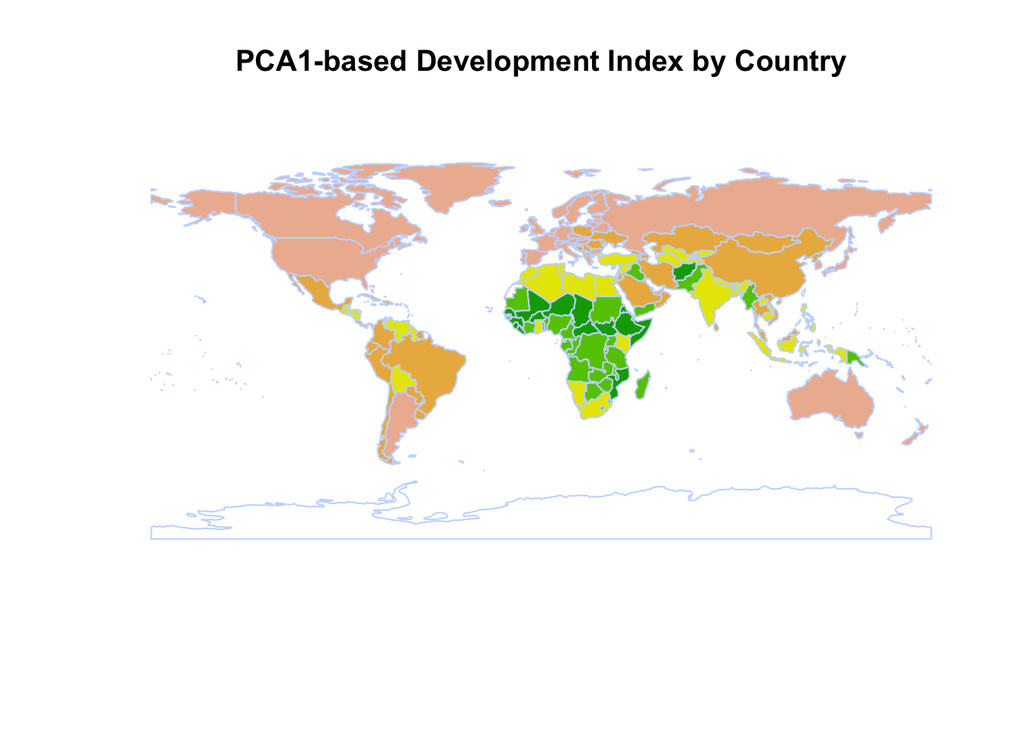

```r
#Draw the map
mapCountryData(matched,nameColumnToPlot="value",missingCountryCol = "white",
               addLegend = FALSE, borderCol = "#C7D9FF",
               catMethod = "pretty", colourPalette = "terrain",
               mapTitle = c("PCA1-based Development Index by Country"), lwd=1)
```

# 6 Conclusions

We have seen how to use PCA to reduce the dimensionality and be ablw to plot countries with more than 10 variables in 2D, as well as how to use the PC1 values to build a development index, intepreting what is the effect of each variable on the component.